# Part 1: Illustration of Method 1 for the IAMI Study

Ann Marie Weideman

2024-01-22

## Overview

This vignette demonstrates how to apply Method 1 presented the manuscript, “Blinded sample size re-estimation for registry-based randomized controlled trials with incomplete event adjudication” by Weideman *et al*.

Data was generated by using demographics information and outcome proportions reported by the Influenza Vaccination After Myocardial Infarction (IAMI) study (Fröbert et al. 2021). The initial sample size calculations were mirrored after their protocol (Fröbert et al. 2017). As such, this data is NOT directly derived from the IAMI study and should not be utilized to guide clinical decision making. You are free to utilize this data in any capacity without license or permission.

The dataset contains treatment arm since it was used to generate associations. However, in practice, the dataset would not include arm since we are blinded to treatment assignment.

## Data description

The primary endpoint for the IAMI study (Fröbert et al. 2021) was a composite of all-cause mortality, myocardial infarction (MI), or stent thrombosis occurring by 12 months post randomization.

Consider a classifying event as one or more of the primary events of interest, and a non-classifying event as an alternative form of the event. For the IAMI study, CV death was considered as a classifying event and non-CV death as a non-classifying event. However, the IAMI study reported only 8 non-CV deaths, and so there were not enough adjudicated non-classifying events to develop a prediction model for Method 2. Thus, Method 1, which does not stratify by the preliminary classification, was utilized. Additionally, we developed an alternative scenario for which a hypothetical study, IAMI2, has a sufficient count of adjudicated classifying and non-classifying events. This scenario is detailed in the section “Part 2: Illustration of Method 2 for the IAMI Study.”

The IAMI study team limited their Cox regression to a single predictor: enrolling site. In contrast, our approach also incorporates adjustments for a history of hypertension (HTN) and previous myocardial infarction (MI), given their known association with the primary outcome. Our first logistic regression model used for prediction also adjusts for event times. Typically, event times are incorporated through survival models to account for censoring. However, our initial prediction model excludes censored observations, making the inclusion of these event times suitable. To ensure these event times are on a comparable scale with binary predictors, they are standardized by subtracting the mean and dividing by the standard deviation. Since this is a blinded analysis, we are naive to treatment arm and cannot include it in the models.

The IAMI study conducted formal adjudication of all primary and secondary endpoints. For the purposes of this demonstration, we assume that their reported outcomes are the adjudicated classifications $Y_1$ and that approximately $50\%$ of the data is adjudicated. We introduce $20\%$ error into the initial classifications $Y_0$ when generating the data.

See the key in the second sheet of `iami1.xlsx` for descriptions of all variables or the header of the data generation `R` script `generate_iami1.R`.

```r
library(openxlsx)
script_path<-setwd(dirname(rstudioapi::getActiveDocumentContext()$path))
iami1 <- read.xlsx(paste0(script_path, "/data/iami1.xlsx"), sheet = "data")

summary(iami1)
```

```
##        y0              y1_obs           y1_true            error
##  Min.   :-1.0000   Min.   :-1.0000   Min.   :-1.0000   Min.   :0.0000
##  1st Qu.:-1.0000   1st Qu.:-1.0000   1st Qu.:-1.0000   1st Qu.:0.0000
##  Median :-1.0000   Median :-1.0000   Median :-1.0000   Median :0.0000
##  Mean   :-0.8918   Mean   :-0.8839   Mean   :-0.8665   Mean   :0.2025
##  3rd Qu.:-1.0000   3rd Qu.:-1.0000   3rd Qu.:-1.0000   3rd Qu.:0.0000
##  Max.   : 1.0000   Max.   : 1.0000   Max.   : 1.0000   Max.   :1.0000
##                    NA's   :1275                        NA's   :2374
##      event           t_event         t_event_scaled        t_risk
##  Min.   :0.0000   Min.   :  0.0091   Min.   :-0.9524   Min.   :0.5001
##  1st Qu.:0.0000   1st Qu.:  4.3075   1st Qu.:-0.6907   1st Qu.:0.7365
##  Median :0.0000   Median : 10.5133   Median :-0.3128   Median :0.9999
##  Mean   :0.0624   Mean   : 15.6489   Mean   : 0.0000   Mean   :0.8713
##  3rd Qu.:0.0000   3rd Qu.: 21.5317   3rd Qu.: 0.3583   3rd Qu.:1.0000
##  Max.   :1.0000   Max.   :129.6264   Max.   : 6.9411   Max.   :1.0000
##
##    t_eligible        adjudicated          arm              htn
##  Min.   :0.009105   Min.   :0.0000   Min.   :0.0000   Min.   :0.0000
##  1st Qu.:0.697127   1st Qu.:0.0000   1st Qu.:0.0000   1st Qu.:0.0000
##  Median :0.966589   Median :0.0000   Median :1.0000   Median :0.0000
##  Mean   :0.841484   Mean   :0.4964   Mean   :0.5024   Mean   :0.4976
##  3rd Qu.:1.000000   3rd Qu.:1.0000   3rd Qu.:1.0000   3rd Qu.:1.0000
##  Max.   :1.000000   Max.   :1.0000   Max.   :1.0000   Max.   :1.0000
##
##       hxmi             site
##  Min.   :0.0000   Min.   :0.0000
##  1st Qu.:0.0000   1st Qu.:0.0000
##  Median :0.0000   Median :1.0000
##  Mean   :0.1588   Mean   :0.5059
##  3rd Qu.:0.0000   3rd Qu.:1.0000
##  Max.   :1.0000   Max.   :1.0000
##
```

```r
# Event rate in placebo (control) arm
p1C<-mean(iami1$y1_true[iami1$arm==0]>0)
round(p1C,3)
```

```
## [1] 0.08
```

```r
# Event rate in vaccine arm
p1T<-mean(iami1$y1_true[iami1$arm==1]>0)
round(p1T,3)
```

```
## [1] 0.046
```

## Estimate sample size at planning stage (stage 0)

```r
# Define parameters
n = nrow(iami1) #total sample size at interim analysis
k = 1 # equal number in tx and placebo
alpha = 0.05 # type 1 error
beta = 1-0.8 # 80% power
z_alpha = qnorm(alpha/2,lower.tail=F)
z_beta = qnorm(beta,lower.tail=F)
t_interim = 1 # time of planned interim analysis in years
```

To demonstrate our methodology, we will analyze the outcome as both a single binary endpoint and as the time to first occurrence of any binary event in the composite endpoint.

The IAMI study assumed that the composite endpoint would be experienced in $10\%$ of participants assigned to placebo and $7.6\%$ of participants assigned to the flu vaccine, corresponding to a hazard ratio (HR) of $0.75$. Assume that sample size was calculated to achieve $80\%$ statistical power and all testing is two-sided with $\alpha=0.05$.

First, we calculate initial sample size for a single binary endpoint.

```r
# Anticipated event rates
p0T <-  0.076
p0C <- 0.1

# Effect size (risk difference)
theta0_bin <-  p0C - p0T

# Weighted event rate
p0 <- (p0C + k*p0T)/(1+k)

# Number required in control
n0C_bin <- (z_alpha*sqrt((1+k)*p0*(1-p0))+
            z_beta*sqrt(k*p0C*(1-p0C)+p0T*(1-p0T)))^2/(k*theta0_bin^2)

# Number required in treatment
n0T_bin <- k*n0C_bin

# Round up
n0C_bin<-ceiling(n0C_bin)
n0T_bin<-ceiling(n0T_bin)
n0_bin<-n0C_bin+n0T_bin
n0_bin
```

```
## [1] 4374
```

Next, we calculate initial sample size for a time-to-event endpoint. Common parameter estimates from the calculations for the binary endpoint are recycled.

```r
# Effect size (hazard ratio)
theta0_tte <- log(1-p0T)/log(1-p0C)

# Number of events
d0 <- ((z_alpha+z_beta)*(1+k*theta0_tte)/(sqrt(k)*(1-theta0_tte)))^2

# Number required in control
n0C_tte <- d0/(k*p0T+p0C)

# Number required in treatment
n0T_tte <- k*n0C_tte

# Round up
n0C_tte<-ceiling(n0C_tte)
n0T_tte<-ceiling(n0T_tte)
n0_tte<-n0C_tte+n0T_tte
n0_tte
```

```
## [1] 4380
```

The IAMI study (Fröbert et al. 2021) was terminated approximately halfway through enrollment ($2532$ total participants, $1272$ to influenza vaccine and $1260$ to placebo) due to COVID. Thus, we are treating the final estimates of event rates in each arm as the rates observed at interim analysis for a hypothetical scenario during which the study continues to enroll until completion. Our simulated data yielded primary event rates of $4.6\%$ for the vaccine group and $8\%$ for the placebo group, which slightly differ from the reported primary event rates of $5.3\%$ for vaccine and $7.2\%$ for placebo in the IAMI study. The discrepancy in these event rates is a result of the simulation’s structure, which incorporates associations between the adjudicated outcome $Y_1$, treatment arm, and multiple predictors, making exact alignment unlikely.

## Re-estimate sample size at interim analysis (stage 1)

We define the function used to carry out Method 1. This function outputs a new dataset of predictions associated with the specified seed.

```r
method1<-function(data, seedling){

  set.seed(seedling)

  #-----------------------------------------------------------------------------
  # Define the W subsets
  #-----------------------------------------------------------------------------
  # A full dataset that excludes treatment arm
  W<-data

  # A subset of W that includes all adjudicated events and non-events with
  # complete follow-up
  # X = x, Y0 in {-1, 0, 1}, Y1 in {-1, 0, 1}, Z=1
  W_adj<-W[W$adjudicated==1,]

  # A subset of W that includes complete adjudications with events
  # X = x, Y0 in {0, 1}, Y1 in {0, 1}, Z = 1
  W_adj_event<-W[W$adjudicated==1 & W$event==1,]

  # A subset of W that includes non-events with complete follow-up (so treated
  # as adjudicated)
  # X = x, Y0 = -1, Y1 = -1, Z = 1
  W_adj_nonevent<-W[W$adjudicated==1 & W$event==0,]

  # A subset of W that includes all unadjudicated events and non-events
  # X = x, Y0 in {-1, 0, 1}, Y1 = NA, Z = 0
  W_unadj<-W[W$adjudicated==0,]

  # A subset of W that includes incomplete adjudications with events
  # X = x, Y0 in {0, 1}, Y1 = NA, Z = 0
  W_unadj_event<-W[W$adjudicated==0 & W$event==1,]

  # A subset of W that includes incomplete adjudications with non-events
  # X = x, Y0 = -1, Y1 = NA, Z = 0
  W_unadj_nonevent<-W[W$adjudicated==0 & W$event==0,]

  #-----------------------------------------------------------------------------
  # Step 1: Fit logistic regression to predict missing Y1 in W_unadj_event
  #-----------------------------------------------------------------------------

  require(MASS)

  # Fit prediction model to patients with adjudicated events
  binom.model<-glm(y1_obs ~ htn + hxmi + site + t_event_scaled,
                    family = binomial,
                    data = W_adj_event)

  # Sample a new set of coefficients from the multivariate normal distribution
  coef.binom <- coef(binom.model)
  cov.binom <- vcov(binom.model)
  sampled.coefs.binom <- mvrnorm(1, mu = coef.binom, Sigma = cov.binom)
  # Update model
  binom.model$coefficients <- sampled.coefs.binom

  # Predict outcomes for patients with unadjudicated events
  prob.binom<-predict(binom.model,
                      newdata=W_unadj_event,
                      type="response")
  pred.binom<-rbinom(nrow(W_unadj_event), 1, prob.binom)

  #-----------------------------------------------------------------------------
  # Step 2: Replace all Y0=-1 and Y1=-1 in W_adj_nonevent
  # with Y0=0 and Y1=0 to correspond to censored observations.
  # Also, replace all Y0=-1 in W_unadj_nonevent with Y0=0 to correspond to
  # censored observations
  #-----------------------------------------------------------------------------

  W_adj_nonevent$y0[W_adj_nonevent$y0==-1]<-0
  W_adj_nonevent$y1_obs[W_adj_nonevent$y1_obs==-1]<-0
  W_unadj_nonevent$y0<-0

 #-----------------------------------------------------------------------------
  # Step 3: Fit Cox proportional hazards model to predict missing Y1 for
  #         event-free participants who are still under observation
  #-----------------------------------------------------------------------------

  W_hat_unadj_event<-W_unadj_event
  # Replace y1_obs with predicted values from step 1
  W_hat_unadj_event$y1_obs<-pred.binom
  W_hat0<-rbind(W_adj_event, W_adj_nonevent, W_hat_unadj_event)

  library(survival)
  # Cox regression
  cox <- coxph(Surv(t_eligible, y1_obs) ~ htn + hxmi + site, data = W_hat0)

  # Sample a new set of coefficients from the multivariate normal distribution
  coef.cox <- coef(cox)
  cov.cox <- vcov(cox)
  sampled.coefs.cox <- mvrnorm(1, mu = coef.cox, Sigma = cov.cox)
  # Update model
  cox$coefficients <- sampled.coefs.cox

  # Predict relative risks for W_unadj_nonevent
  rr <- predict(cox, newdata = W_unadj_nonevent, type = "risk")

  # Estimate the baseline hazard function using Breslow's estimator
  baseline_h <- basehaz(cox, centered = FALSE)

  # Function to interpolate baseline hazard for each time point
  interpolate_hazard <- function(time_points, baseline_h) {
    sapply(time_points, function(time) {
      if(any(baseline_h$time >= time)) {
        idx <- which.max(baseline_h$time[baseline_h$time <= time])
        return(baseline_h$hazard[idx])
      } else {
        return(NA)
      }
    })
  }

  # Interpolate the baseline hazard for each time point in W_unadj_nonevent
  interpolated_baseline_h <- interpolate_hazard(W_unadj_nonevent$t_eligible,
                                                baseline_h)

  # Calculate absolute hazard rates
  h <- interpolated_baseline_h * rr

  # Calculate conditional probability of an event between time t_eligible and
  # t_interim
  prob.cox<-1-exp(-h*(t_interim-W_unadj_nonevent$t_eligible))
  pred.cox<-rbinom(nrow(W_unadj_nonevent),1,prob.cox)

  #-----------------------------------------------------------------------------
  # Step 4: Combine datasets and output
  #-----------------------------------------------------------------------------
  W_unadj_nonevent$y1_obs<-pred.cox
  W_hat<-rbind(W_hat0, W_unadj_nonevent)

  return(W_hat)

}
```

Within the function, the adjudicated outcomes are sampled from a binomial distribution with parameter equal to the predicted probabilities. Since a single random sample of binomial random variates may not accurately represent the underlying distribution for the adjudicated outcomes, we repeat the routine a total of 100 times, using a different seed within each routine, and combine the resulting datasets.

```r
combo_data<-data.frame()
for(i in 1:100){
  out_data<-method1(iami1,seedling=i)
  combo_data<-rbind(combo_data,out_data)
}

# Estimate pooled event rates across combined datasets
adj_ids<-which(combo_data$adjudicated==1)
unadj_ids<-which(combo_data$adjudicated==0)

# Truth
p1_true<-mean(iami1$y1_true>0)
# Method 2
p1_method1<-mean(combo_data$y1_obs)
# Complete case
p1_complete_case<-mean(combo_data$y1_obs[adj_ids])
# Carry forward
p1_carry_forward<-mean(c(combo_data$y1_obs[adj_ids],combo_data$y0[unadj_ids]))

est_n1_bin<-function(p1_hat){
  n1_hat<-(z_alpha+z_beta)^2*(1+k)^2*p1_hat*(1-p1_hat)/(k*theta0_bin^2)
  return(ceiling(n1_hat))
}

est_n1_tte<-function(p1_hat){
    n1_hat<-d0/p1_hat
    return(ceiling(n1_hat))
}

# True re-estimated n
n1_bin_true <- est_n1_bin(p1_true)
n1_tte_true <- est_n1_tte(p1_true)

# Method 1 re-estimated n
n1_bin_method1 <- est_n1_bin(p1_method1)
n1_tte_method1 <- est_n1_tte(p1_method1)

# Complete case re-estimated n
n1_bin_complete_case <- est_n1_bin(p1_complete_case)
n1_tte_complete_case <- est_n1_tte(p1_complete_case)

# Carry forward re-estimated n
n1_bin_carry_forward <- est_n1_bin(p1_carry_forward)
n1_tte_carry_forward <- est_n1_tte(p1_carry_forward)

n1_hat<-c(n1_bin_true, n1_bin_method1, n1_bin_complete_case, n1_bin_carry_forward,
          n1_tte_true, n1_tte_method1, n1_tte_complete_case, n1_tte_carry_forward)
```

The sample size estimates no longer coincide for binary and time-to-event endpoints. We now observe that, for the binary endpoint, the required sample size is lower than our initial estimate (originally $4374$, now revised to $3123$), while, for the time-to-event endpoint, it exceeds the initial estimate (originally $4380$, now revised to $6318$). Based on the criteria outlined in the main text, the study will proceed with the initially planned sample size for the binary endpoint, as the re-calculated sample size is smaller than the original estimate.

In this specific example, $\widehat{p}_1 = 0.061$ is smaller than the anticipated pooled event rate of $p_0 = 0.088$ and deviates from the truth of $\widehat{p}_1 = 0.063$ by $0.002$. In the binomial case, as $\widehat{p}_1$ approaches 1 from a value greater than 0.5, the term $\widehat{p}_1(1-\widehat{p}_1)$ in the numerator of the formula for $\widehat{n}_1$ results in a decrease in the required sample size. In contrast, in a time-to-event scenario, any decrease in $\widehat{p}_1$ causes the denominator of the formula for $\widehat{n}_1$ to decrease. Consequently, since $\widehat{p}_1$ is smaller than the anticipated value of $p_0$, a larger re-estimated sample size is sufficient to achieve the necessary number of events.

Note that the complete case estimate of $0.054$ and the carry forward estimate of $0.052$ are both biased downward compared to the true value of $0.063$.

Finally, the $70\%$ CIs for the re-estimated sample size can be generated using the closed form expressions defined in the main text.

```r
# Functions to compute closed form CIs
# Binary endpoint
binary_ci<-function(n1_hat, p1_hat, alpha){
  z_alpha2<-qnorm(alpha/2, lower.tail=F)
  se<-((z_alpha+z_beta)^2*(1+k)^2/(k*theta0_bin^2)*
                            sqrt(p1_hat*(1-p1_hat)*(1-2*p1_hat)^2/n))
  lb<-ceiling(n1_hat-z_alpha2*se)
  ub<-ceiling(n1_hat+z_alpha2*se)

  return(c(lb,ub))
}

# Time-to-event endpoint
tte_ci<-function(n1_hat, p1_hat, alpha){
  z_alpha2<-qnorm(alpha/2, lower.tail=F)
  se<-sqrt((1-p1_hat)/(n*p1_hat))
  lb<-ceiling(exp(log(n1_hat)-z_alpha2*se))
  ub<-ceiling(exp(log(n1_hat)+z_alpha2*se))

  return(c(lb,ub))
}

# CI limits for closed form CIs
Lower<-ceiling(c(binary_ci(n1_bin_true, p1_true, 0.30)[1],
                 binary_ci(n1_bin_method1, p1_method1, 0.30)[1],
                 binary_ci(n1_bin_complete_case, p1_complete_case, 0.30)[1],
                 binary_ci(n1_bin_carry_forward, p1_carry_forward, 0.30)[1],
                 tte_ci(n1_tte_true, p1_true, 0.30)[1],
                 tte_ci(n1_tte_method1, p1_method1, 0.30)[1],
                 tte_ci(n1_tte_complete_case, p1_complete_case, 0.30)[1],
                 tte_ci(n1_tte_carry_forward, p1_carry_forward, 0.30)[1]))
Upper<-ceiling(c(binary_ci(n1_bin_true, p1_true, 0.30)[2],
                 binary_ci(n1_bin_method1, p1_method1, 0.30)[2],
                 binary_ci(n1_bin_complete_case, p1_complete_case, 0.30)[2],
                 binary_ci(n1_bin_carry_forward, p1_carry_forward, 0.30)[2],
                 tte_ci(n1_tte_true, p1_true, 0.30)[2],
                 tte_ci(n1_tte_method1, p1_method1, 0.30)[2],
                 tte_ci(n1_tte_complete_case, p1_complete_case, 0.30)[2],
                 tte_ci(n1_tte_carry_forward, p1_carry_forward, 0.30)[2]))
```

## Plot results

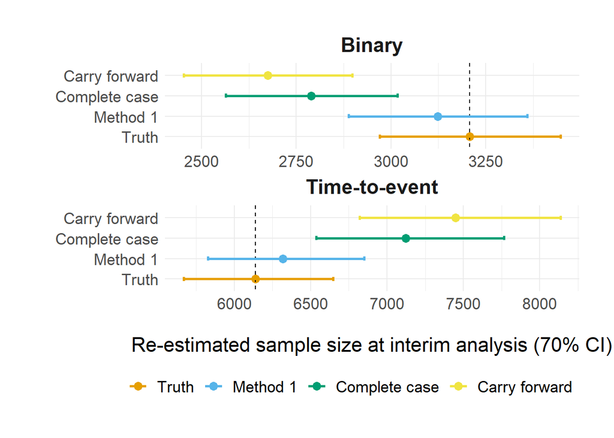

```r
library(ggplot2)
library(dplyr)

data <- data.frame(
  Method = rep(c("Truth", "Method 1", "Complete case", "Carry forward"), 2),
  Type = factor(rep(c("Binary", "Time-to-event"), each = 4)),
  n1_hat = n1_hat, # re-estimated sample sizes
  Lower = Lower, # lower limits of CIs
  Upper = Upper # upper limits of CIs
)

# Re-order levels for plot
data$Method <- factor(data$Method,
                      levels = c("Truth", "Method 1",
                                 "Complete case", "Carry forward"))

# Add a column for a vertical line denoting the truth
data$VLine <- ifelse(data$Type == "Binary", n1_hat[1], n1_hat[5])

# Define color-blind friendly colors for each method
method_colors <- c(
  "Truth" = "#E69F00",  # Orange
  "Method 1" = "#56B4E9",  # Sky Blue
  "Complete case" = "#009E73",  # Bluish Green
  "Carry forward" = "#F0E442"   # Yellow
)

plot <- ggplot(data, aes(x = Method, y = n1_hat, color = Method)) +
  geom_point(size = 3) +
  geom_abline(aes(intercept = VLine, slope = 0), linetype = "dashed") +
  geom_errorbar(aes(ymin = Lower, ymax = Upper), width = 0.2, size = 1) +
  theme_minimal() +
  labs(x="", y = "Re-estimated sample size at interim analysis (70% CI)") +
  coord_flip() +
  scale_color_manual(values = method_colors) +
  facet_wrap(~ Type, scales = "free", ncol = 1) +
  theme(plot.margin = margin(1, 1, 1, 1, "cm"),
    strip.text = element_text(face = "bold", size = rel(1.5), margin = margin(b = 8)),
    legend.position = "bottom",
    legend.justification = "right",
    legend.direction = "horizontal",
    legend.box.just = "right",
    axis.title.x = element_text(margin = margin(t = 20), size=rel(1.5)),
    axis.title.y = element_text(size = rel(1.4)),  # Increase Y axis title size
    axis.text.x = element_text(size = rel(1.5)),   # Increase X axis text size
    axis.text.y = element_text(size = rel(1.5)),   # Increase Y axis text size
    legend.text = element_text(size = rel(1.2)),   # Increase legend text size
    legend.title = element_text(size = rel(1.3))   # Increase legend title size
  ) +
  guides(color = guide_legend(title = NULL))

print(plot)
```

## References

Fröbert, Ole, Matthias Götberg, Oskar Angerås, Lena Jonasson, David Erlinge, Thomas Engstrøm, Jonas Persson, et al. 2017. “Design and Rationale for the Influenza Vaccination After Myocardial Infarction (IAMI) Trial. A Registry-Based Randomized Clinical Trial.” *American Heart Journal* 189: 94–102. https://doi.org/https://doi.org/10.1016/j.ahj.2017.04.003.

Fröbert, Ole, Matthias Götberg, David Erlinge, Zubair Akhtar, Evald H. Christiansen, Chandini R. MacIntyre, Keith G. Oldroyd, et al. 2021. “Influenza Vaccination After Myocardial Infarction: A Randomized, Double-Blind, Placebo-Controlled, Multicenter Trial.” *Circulation* 144 (18): 1476–84. https://doi.org/10.1161/CIRCULATIONAHA.121.057042.